# Task 2: Hierarchical clustering (PELEGRI)

Patrick Pelegri-O’Day

2/14/2022

### Overview

This report uses hierarchical clustering by complete linkage to create a dendogram showing multivariate clustering for water chemistry by site. A tanglegram is generated to show how clustering using single linkage and complete linkage differ. The data are drawn from six Santa Barbara Coastal Long Term Ecological Research (LTER) sites. Monitoring has been ongoing since year 2000.

**Citation:** Santa Barbara Coastal LTER and J. Melack. 2019. SBC LTER: Land: Stream chemistry in the Santa Barbara Coastal drainage area, ongoing since 2000 ver 16. Environmental Data Initiative. https://doi.org/10.6073/pasta/67a558a24ceed9a0a5bf5e46ab841174.

### Setup

```r
knitr::opts_chunk$set(echo = TRUE, message = FALSE, warning = FALSE)

library(here)
library(tidyverse)
library(naniar)
library(dendextend)
library(ggdendro)
```

```r
water_raw_df <- read_csv(here('data', 'sbc_lter_registered_stream_chemistry.csv'))
```

Prepare data for clustering

```r
# Replace values of -999.0 with 'NA' in all columns so that they don't skew analysis
water_dropna_df <- water_raw_df %>%
  replace_with_na_all(condition = ~.x == -999.0)
```

To perform hierarchical clustering by site, we need to reformat the data so that the data are arranged in a single summary row per site based on means from all observations at that site.

```r
# Group by site code and summarize to get mean of each variable
water_summarize_df <- water_dropna_df %>%
  group_by(site_code) %>% # for each site...
  summarize_all(mean, na.rm = TRUE)  # ...take mean of each column

# Remove character variables and scale numerical values
water_scaled_df <- water_summarize_df %>%
  select(-timestamp_local, -site_code) %>% # drop character variables
  scale() # make column vectors comparable in scale

# Make site code row name
rownames(water_scaled_df) <- water_summarize_df$site_code
```

Calculate distance matrix using Euclidean distance

```r
euc_distance <- dist(water_scaled_df, method = 'euclidean', diag = TRUE, upper = TRUE)
```

### Clustering analysis

Complete linkage clustering

```r
hc_complete <- hclust(euc_distance, method = 'complete')
```

Single linkage clustering

```r
hc_single <- hclust(euc_distance, method = 'single')
```

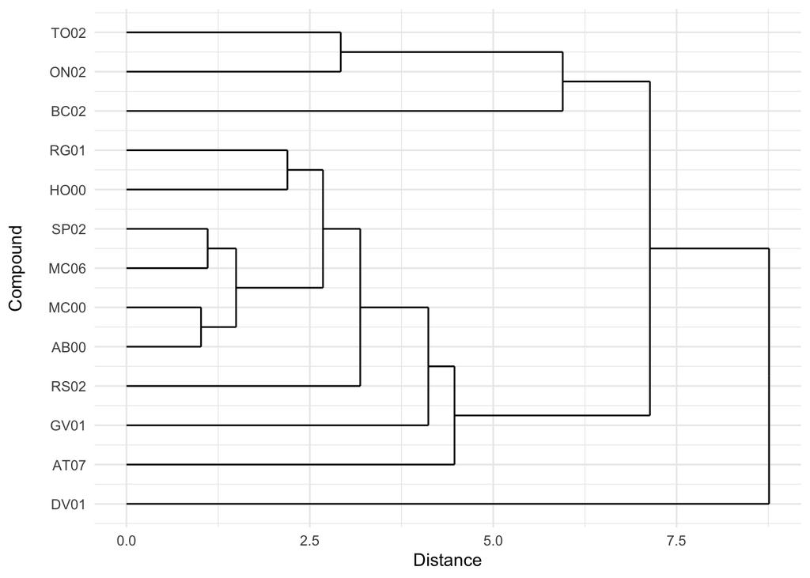

```r
ggdendrogram(hc_complete, rotate = TRUE) +
  theme_minimal() +
  labs(x = 'Compound\n', y = 'Distance')
```

**Figure 1:** Dendrogram of hierarchical clustering by complete linkage for water chemistry by site in Santa Barbara Coastal LTER based on data from 2000 to 2005.

**Dendrogram takeaways**

- There are three main clusters in the data: one that contains the top 3 sites on the graph (TO02, ON02, and BC02), one that contains the subsequent 9 sites on the graph, and one that contains a single site at the bottom (DV01).
- These clusters indicate stream sites whose water chemistry is most similar to each other.

Make tanglegram to compare clustering from single and complete linkage

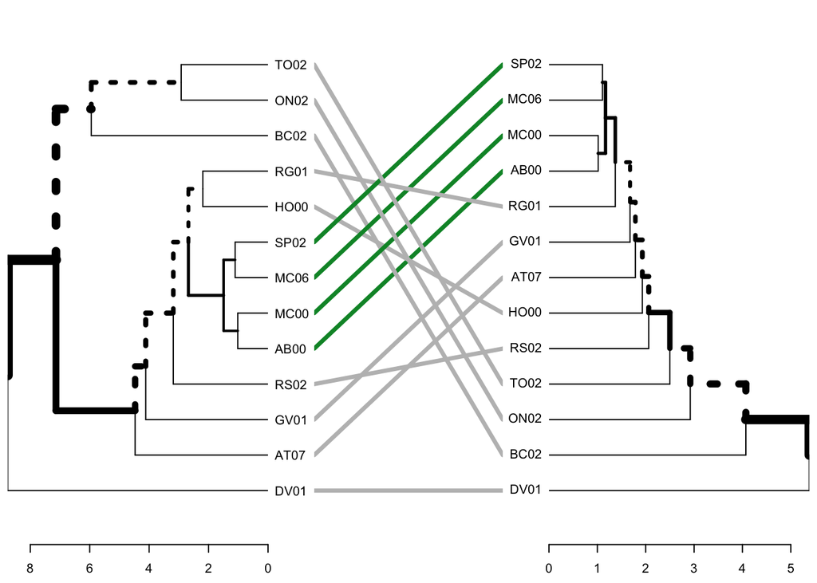

```r
### convert to class dendrogram
dend_complete <- as.dendrogram(hc_complete)
dend_single <- as.dendrogram(hc_single)

tanglegram(dend_complete, dend_single)
```

**Figure 2:** Tanglegram of hierarchical clustering by complete linkage vs. single linkage for water chemistry by site in the Santa Barbara Coastal LTER based on data from 2000 to 2005.

**Tanglegram takeaways:**

- Most stream sites (9 out of 13) are grouped differently when comparing clustering results by complete linkage vs. single linkage.